# Settlement Persistence Project, SBOM Script #3:

Least Cost Paths and Cost Distance Matrices

Rudolf Cesaretti

Last run on 2022-07-03

The sole purpose of Script #3 is to calculate least cost paths (LCPs) for the SBOM dataset for each of the 17 modelling periods. There are two sets of outputs:

1. Least cost path distance matrices saved as .csv files for use throughout the subsequent scripts
2. Least cost path rasters used to calculate “Transport Route Density” for site catchment areas in script 4

**These least cost paths are very computationally intensive to calculate (even from a 90m DEM), *requiring several days of computation time* (see below for details).**

# 1 Setup

All of the data and scripts are downloadable from the [new ASU SettlementPersist2022 github repository](https://https://github.com/rcesaret/ASUSettlementPersist2022), which can be downloaded locally as a .zip folder or cloned to your own account.

Either way, once you have done so, you will need to modify the working directory (setwd(“C:/…)”) path and “dir” variables in the code chunk below to match the repository location on your computer.

```r
wd <- list()

# SET YOUR LOCAL DIRECTORY LOCATION HERE:
wd$dir <- "C:/Users/rcesaret/Dropbox (ASU)/ASUSettlementPersist2022/"
# wd$dir <- 'C:/Users/TJ McMote/Dropbox (ASU)/ASUSettlementPersist2022'

wd$analysis <- paste0(wd$dir, "analysis/")
wd$data_r <- paste0(wd$dir, "data-raw/")
wd$data_p <- paste0(wd$dir, "data-processed/")
wd$data_f <- paste0(wd$dir, "data-final-outputs/")
wd$figs <- paste0(wd$dir, "figures/")
wd$funcs <- paste0(wd$dir, "functions/")
```

## 1.1 Load R Packages and Custom Functions

```r
# Package names
packages <- c("rgdal", "rgeos", "sp", "sf", "GISTools", "raster", "Matrix",
    "gdistance", "leastcostpath", "lwgeom", "tidyverse", "tidyr")

# Install packages not yet installed
installed_packages <- packages %in% rownames(installed.packages())
if (any(installed_packages == FALSE)) {
    install.packages(packages[!installed_packages])
}

# load packages
invisible(lapply(packages, library, character.only = TRUE))

rm(packages, installed_packages)

# Read in custom R function located in the wd$funcs directory folder
source(paste0(wd$funcs, "splitByAttributes.R"))
```

## 1.2 Import Data

```r
# Read-in the data
All_AggPoly <- readOGR(paste0(wd$data_p, "SBOM_AggPoly2.gpkg"))
# read in 90m DEM and convert the CRS to the same as spatial points
# dataframe
DEM <- raster(paste0(wd$data_r, "SBOM_DEM_90m.tif"))
DEM <- projectRaster(DEM, crs = 26914)
```

# 2 Reorganize Data from Step #2

```r
# convert spatial polygons dataframe to spatial points dataframe
coor = All_AggPoly@data[, c("East", "North")]  #create separate dataframe of coordinates for spatial points dataframe
rownames(coor) <- as.numeric(rownames(coor))  #make sure rownames match
All_AggPts <- SpatialPointsDataFrame(coor, All_AggPoly@data, match.ID = TRUE)  #convert to spatial points dataframe
proj4string(All_AggPts) <- CRS("+proj=utm +zone=14 +datum=NAD83 +units=m +no_defs")  #make sure CRS matches polygons
All_AggPts = as(st_make_valid(st_as_sf(All_AggPts)), "Spatial")  #make sure geometry is valid

# reorder spatial points dataframe by period
All_AggPts <- All_AggPts[order(All_AggPts$PeriodNum), ]

# Split points by Phase, saved as list of spatial points dataframes
Plist <- splitByAttributes(spdata = All_AggPts, attr = "Period", suffix = "_Pts")

# rename spatial points dataframes to include period numbers as prefix
PeriodNums <- list("1", "2", "3", "4", "5", "6", "7", "8", "9", "10", "11",
    "12", "13", "14", "15", "16", "17")  #include period number
names(Plist) <- paste0(PeriodNums, "_", names(Plist))

rm(PeriodNums)
```

# 3 Least Cost Paths: Distance Matrices and Rasters

Here is where we calculate…

1. Least cost path distance matrices saved as .csv files for use throughout scripts 4 and 5
   - Cost-Distance Matrix = Cost-distance matrix from all sites to all sites within a single period. Calculated from the centroid locations of site polygons and a cost-surface generated from topographic GIS data (DEM).
   - Here, the cost surface employed is Tobler’s ’Hiking Function’ (the most widely used cost function when approximating the difficulty of moving across a landscape), which is a simple parameterization of slope.
   - For more options, see the [R leastcostpath package](https://cran.r-project.org/web/packages/leastcostpath/index.html) (Lewis, 2022)
2. Least cost path rasters used to calculate “Transport Route Density” for site catchment areas in script 4
   - Transport Route Density = The number or fraction of all least cost paths that cross through a settlement’s catchment area; measures the centrality of settlements in hypothetical transport networks
   - leastcostpath -> create_lcp_density -> Creates a cumulative Least Cost Path Raster

## 3.1 **WARNING!! RUNNING THIS SCRIPT WILL TAKE SEVERAL DAYS!!**

- Intel(R) Core(TM) i7-4790 CPU @ 3.60GHz
- octa-core processor
- 32 GB of RAM

**NOTE:** The “create_lcp_network” function from the “leastcostpath” package – which takes the most time by-far – already uses parallel processing (Lewis, 2022). However, the “create_lcp_density” (raster computation from SpatialLinesDataFrames) does not. Future implementations *might* improve speed a little bit by defining a wrapper function for “create_lcp_density” that implements a multi-core setup using the “parallel” and “doParallel” R packages.

```r
# create vectors of names for outputs
nam.distmat <- c("EF_cdmat", "EF_MF_cdmat", "MF_cdmat", "MF_LF_cdmat", "LF_cdmat",
    "LF_TF_cdmat", "TF_cdmat", "TF_CL_cdmat", "CL_cdmat", "CL_ET_cdmat", "ET_cdmat",
    "ET_LTAzI_cdmat", "LTAzI_cdmat", "LTAzI_EA_cdmat", "EA_cdmat", "EA_LA_cdmat",
    "LA_cdmat")
nam.dens <- c("EF_lcpdens", "EF_MF_lcpdens", "MF_lcpdens", "MF_LF_lcpdens",
    "LF_lcpdens", "LF_TF_lcpdens", "TF_lcpdens", "TF_CL_lcpdens", "CL_lcpdens",
    "CL_ET_lcpdens", "ET_lcpdens", "ET_LTAzI_lcpdens", "LTAzI_lcpdens", "LTAzI_EA_lcpdens",
    "EA_lcpdens", "EA_LA_lcpdens", "LA_lcpdens")
CD.mats <- list()
lcp.dens.r <- list()


slope_cs <- create_slope_cs(DEM, cost_function = "tobler")

for (i in 1:length(Plist)) {

    tmp <- Plist[[i]]  #centroid spdf for period i to temp object

    # create neighbor matrix among all sites in period i
    nb.mat = t(as.matrix(combn(1:nrow(tmp), 2, simplify = TRUE)))

    # calculate least cost path network among all sites in period i
    lcp_net <- create_lcp_network(cost_surface = slope_cs, locations = tmp,
        nb_matrix = nb.mat, cost_distance = T, parallel = T, ncores = 6)

    # use lcp network to create lcp density raster for period i
    lcp.dens <- create_lcp_density(lcp_net, DEM)
    lcp.dens.r[[i]] <- lcp.dens

    # export lcp densities as .grd raster for period i
    writeRaster(lcp.dens.r[[i]], filename = paste0(wd$data_p, "lcp_dens_rasts/",
        nam.dens[i], ".grd"), format = "raster", overwrite = F)

    # convert to matrix format, name cols/rows, and save into output list
    edge = rbind(lcp_net@data, data.frame(from = c(1:nrow(tmp)), to = c(1:nrow(tmp)),
        cost = c(rep(0, nrow(tmp)))))
    xxx = xtabs(cost ~ from + to, data = edge)
    xxx = as.matrix(Matrix::forceSymmetric(matrix(xxx, nrow = nrow(xxx), ncol = ncol(xxx))))
    colnames(xxx) <- tmp$AggSite
    rownames(xxx) <- tmp$AggSite
    CD.mats[[i]] <- xxx

    # export cost dist matrix for period i as .csv files for steps #4-5
    write.csv(CD.mats[[i]], file = paste0(wd$data_p, "CDMatrices/", nam.distmat[i],
        ".csv"))
    write.csv(CD.mats[[i]], file = paste0(wd$data_f, "CDMatrices/", nam.distmat[i],
        ".csv"))
}

# name objects in the output lists
names(CD.mats) <- nam.distmat
names(lcp.dens.r) <- nam.dens

rm(xxx, lcp.dens, edge, DEM, lcp_net, nb.mat, tmp, slope_cs)
```

## 3.2 Fast Alternative: Simple Geodesic Distance Matrices

While the “Transport Route Density” least cost path rasters must be calculated as above, we *can* use non-LCP geodesic ‘great circle’ distances instead of LCP cost-distances. The advantage here is that geodesic distance matrices can be calculated in just a few seconds using the code below.

```r
# create vectors of names for outputs
nam.distmat <- c("EF_dmat", "EF_MF_dmat", "MF_dmat", "MF_LF_dmat", "LF_dmat",
    "LF_TF_dmat", "TF_dmat", "TF_CL_dmat", "CL_dmat", "CL_ET_dmat", "ET_dmat",
    "ET_LTAzI_dmat", "LTAzI_dmat", "LTAzI_EA_dmat", "EA_dmat", "EA_LA_dmat",
    "LA_dmat")

D.mats <- list()

for (i in 1:length(Plist)) {
    tmp <- Plist[[i]]
    x = pointDistance(tmp@coords, lonlat = F, allpairs = T)
    rownames(x) <- tmp$AggSite
    colnames(x) <- tmp$AggSite
    D.mats[[i]] <- x
    write.csv(D.mats[[i]], file = paste0(wd$data_p, "DMatrices/", nam.distmat[i],
        ".csv"))
}

names(D.mats) <- nam.distmat

rm(x, tmp)
```

As seen in the graph below, there is a strong, positive linear relationship between the LCP cost-distances and geodesic distances. With geodesic distance explaining over 99% of the variability in LCP cost-distance, there is very little difference overall between the two.

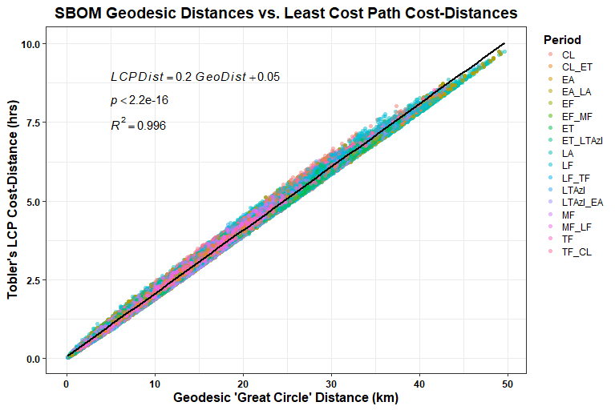

In spite of this global similarity, local distances between sites could be affected substantially (e.g. if the geodesic paths cross limiting terrain). As such, this geodesic work-around should be used provisionally until the LCP cost-distances can be computed properly.

Cases where we would expect a salient **global** difference between LCP and geodesic distances include cases with:

- impassable or highly-penalized terrain
- known transport networks
- meaningful study region borders violated by “straight” (geodesic) lines

# References

Lewis, J. (2022). *Leastcostpath: Modelling pathways and movement potential within a landscape*. https://CRAN.R-project.org/package=leastcostpath